# KAGGLE PROJECT HOUSE PREDICTION

Abhiram Mannam, Abinav Yadamani, Gnana Chaithanya Rawali Male, Neil Samuel Sadanand Pulukuri

2023-04-16

### Introduction

The aim of this project is to predict the house prices in Ames, Iowa with the given variables (predictors) and predict the SalePrice (Target Variable). Every home buyer wants to purchase their ideal home, but it can be challenging to estimate the cost of a home as their could be many factors that needs to considered to arrive at the price. To overcome this, our Linear Regression model will estimate the price of the house using the predictor variables which are most sought to influence the sales price of a house. The benchmark for this model is to have r-squared above 0.85 using any number of predictors (variables).

### Import and explore the datasets.

```r
knitr::opts_chunk$set(echo = TRUE)
library(tidyverse) #Importing the Library tidyverse.
library(DescTools)
library(gt)
```

Importing the train and test data in csv formats.

```r
train <- read_csv("train.csv") # Get the Train set data.
test <- read_csv("test.csv") # Get the Test set data.
```

Exploring the dataframe structure for the train set and test set to glance at the variables and their data types.

```r
str(train)# To get the structure of the train dataset.
```

```r
str(test)
```

### Missing Values

To obtain the count of the missing values in the train dataset, we have created a function “count_missings” which inturn uses the is.na() function.

```r
count_missings <- function(x) sum(is.na(x))
train %>%
  summarize_all(count_missings)%>%
  gt(caption = "Table 1. Number of Missing Values for each predictor in Train dataset.")
```

Table 1. Number of Missing Values for each predictor in Train dataset.

| Id | MSSubClass | MSZoning | LotFrontage | LotArea | Street | Alley | LotShape | LandContour | Utilities | LotConfig | LandSlope | Neighborhood | Condition1 | Condition2 | BldgType | HouseStyle | OverallQual | OverallCond | YearBuilt | YearRemodAdd | RoofStyle | RoofMatl | Exterior1st | Exterior2nd | MasVnrType | MasVnrArea | ExterQual | ExterCond | Foundation | … |
| --- | --- | --- | --- | --- | --- | --- | --- | --- | --- | --- | --- | --- | --- | --- | --- | --- | --- | --- | --- | --- | --- | --- | --- | --- | --- | --- | --- | --- | --- | --- |
| 0 | 0 | 0 | 259 | 0 | 0 | 1369 | 0 | 0 | 0 | 0 | 0 | 0 | 0 | 0 | 0 | 0 | 0 | 0 | 0 | 0 | 0 | 0 | 0 | 0 | 8 | 8 | 0 | 0 | 0 | … |

```r
sum(is.na(train))
```

```
## [1] 6965
```

> There are 6965 missing values in the train dataset. For instance, Alley has 1369 and PoolQC has 1453 missing values.

Based on the data description provided at Kaggle, the missing data for the variables are imputed with either the median (for numeric type) or with the mode or None (character type). GarageYrBlt character variable has been imputed and replaced with None for the missing values.

```r
train <- train %>%
  mutate(LotFrontage = replace_na (LotFrontage,median(LotFrontage, na.rm = TRUE)),
         Alley = replace_na (Alley, replace = "None"),
         MasVnrType = replace_na (MasVnrType, replace = "None"),
         MasVnrArea = replace_na (MasVnrArea, replace = median(MasVnrArea, na.rm = TRUE)),
         BsmtQual = replace_na (BsmtQual, replace = "None"),
         BsmtCond = replace_na (BsmtCond, replace = "None"),
         BsmtExposure = replace_na (BsmtExposure, replace = "None"),
         BsmtFinType1 = replace_na (BsmtFinType1, replace = "None"),
         BsmtFinType2 = replace_na (BsmtFinType2, replace = "None"),
         Electrical = replace_na(Electrical,Mode(Electrical, na.rm = TRUE)),
         FireplaceQu = replace_na (FireplaceQu, replace = "None"),
         GarageType = replace_na (GarageType, replace = "None"),
         GarageYrBlt = ntile(GarageYrBlt, 5) %>% as.character() ,GarageYrBlt = replace_na(GarageYrBlt, "none"),
         GarageFinish = replace_na (GarageFinish, replace = "None"),
         GarageQual = replace_na (GarageQual, replace = "None"),
         GarageCond = replace_na (GarageCond, replace = "None"),
         PoolQC = replace_na (PoolQC, replace = "None"),
         Fence = replace_na(Fence, replace = "None"),
         MiscFeature = replace_na(MiscFeature , replace = "None")
         )
```

```r
train %>%
  summarize_all(count_missings)%>%
   gt(caption = "Table 2. Number of Missing Values for each predictor in Train dataset after cleaning.")
```

Table 2. Number of Missing Values for each predictor in Train dataset after cleaning.

| Id | MSSubClass | MSZoning | LotFrontage | LotArea | Street | Alley | LotShape | LandContour | Utilities | LotConfig | LandSlope | Neighborhood | Condition1 | Condition2 | BldgType | HouseStyle | OverallQual | OverallCond | YearBuilt | YearRemodAdd | RoofStyle | RoofMatl | Exterior1st | Exterior2nd | MasVnrType | MasVnrArea | ExterQual | ExterCond | Foundation | … |
| --- | --- | --- | --- | --- | --- | --- | --- | --- | --- | --- | --- | --- | --- | --- | --- | --- | --- | --- | --- | --- | --- | --- | --- | --- | --- | --- | --- | --- | --- | --- |
| 0 | 0 | 0 | 0 | 0 | 0 | 0 | 0 | 0 | 0 | 0 | 0 | 0 | 0 | 0 | 0 | 0 | 0 | 0 | 0 | 0 | 0 | 0 | 0 | 0 | 0 | 0 | 0 | 0 | 0 | … |

```r
sum(is.na(train))
```

```
## [1] 0
```

The above table confirms that all the missing values have been imputed and Train data is ready for developing the model.

```r
test %>%
  summarize_all(count_missings)%>%
  gt(caption="Table 3. Number of Missing Values for each predictor in Test dataset.")
```

Table 3. Number of Missing Values for each predictor in Test dataset.

| Id | MSSubClass | MSZoning | LotFrontage | LotArea | Street | Alley | LotShape | LandContour | Utilities | LotConfig | LandSlope | Neighborhood | Condition1 | Condition2 | BldgType | HouseStyle | OverallQual | OverallCond | YearBuilt | YearRemodAdd | RoofStyle | RoofMatl | Exterior1st | Exterior2nd | MasVnrType | MasVnrArea | ExterQual | ExterCond | Foundation | … |
| --- | --- | --- | --- | --- | --- | --- | --- | --- | --- | --- | --- | --- | --- | --- | --- | --- | --- | --- | --- | --- | --- | --- | --- | --- | --- | --- | --- | --- | --- | --- |
| 0 | 0 | 4 | 227 | 0 | 0 | 1352 | 0 | 0 | 2 | 0 | 0 | 0 | 0 | 0 | 0 | 0 | 0 | 0 | 0 | 0 | 0 | 0 | 1 | 1 | 16 | 15 | 0 | 0 | 0 | … |

Now, the same Train cleaning process is followed to clean the Test dataset i.e., missing variables are imputed with either the median (for numeric type)or with the mode or None (character types).

```r
test <- test %>%
  mutate(MSZoning = replace_na(MSZoning,Mode(MSZoning, na.rm = TRUE)),
         LotFrontage = replace_na (LotFrontage,median(LotFrontage, na.rm = TRUE)),
         Alley = replace_na (Alley, replace = "None"),
         Utilities = replace_na(Utilities,Mode(Utilities, na.rm = TRUE)),
         Exterior1st = replace_na(Exterior1st,Mode(Exterior1st, na.rm = TRUE)),
         Exterior2nd = replace_na(Exterior2nd,Mode(Exterior2nd, na.rm = TRUE)),
         MasVnrType = replace_na (MasVnrType, replace = "None"),
         MasVnrArea = replace_na (MasVnrArea, replace = median(MasVnrArea, na.rm = TRUE)),
         BsmtQual = replace_na (BsmtQual, replace = "None"),
         BsmtCond = replace_na (BsmtCond, replace = "None"),
         BsmtExposure = replace_na (BsmtExposure, replace = "None"),
         BsmtFinType1 = replace_na (BsmtFinType1, replace = "None"),
         BsmtFinSF1 = replace_na (BsmtFinSF1,0),
         BsmtFinType2 = replace_na (BsmtFinType2, replace = "None"),
         BsmtFinSF2 = replace_na (BsmtFinSF2,median(BsmtFinSF2, na.rm = TRUE)),
         BsmtUnfSF = replace_na (BsmtUnfSF,median(BsmtUnfSF, na.rm = TRUE)),
         TotalBsmtSF = replace_na (TotalBsmtSF,median(TotalBsmtSF, na.rm = TRUE)),
         BsmtFullBath = replace_na (BsmtFullBath,median(BsmtFullBath, na.rm = TRUE)),
         BsmtHalfBath = replace_na (BsmtHalfBath,median(BsmtHalfBath, na.rm = TRUE)),
         KitchenQual = replace_na(KitchenQual,Mode(KitchenQual, na.rm = TRUE)),
         Functional = replace_na(Functional,Mode(Functional, na.rm = TRUE)),
         FireplaceQu = replace_na (FireplaceQu, replace = "None"),
         GarageType = replace_na (GarageType, replace = "None"),
         GarageYrBlt = ntile(GarageYrBlt, 5) %>% as.character() ,GarageYrBlt = replace_na(GarageYrBlt, "none"),
         GarageFinish = replace_na (GarageFinish, replace = "None"),
         GarageCars = replace_na(GarageCars,Mode(GarageCars, na.rm = TRUE)),
         GarageArea = replace_na (GarageArea,median(GarageArea, na.rm = TRUE)),
         GarageQual = replace_na (GarageQual, replace = "None"),
         GarageCond = replace_na (GarageCond, replace = "None"),
         PoolQC = replace_na (PoolQC, replace = "None"),
         Fence = replace_na(Fence, replace = "None"),
         MiscFeature = replace_na(MiscFeature , replace = "None"),
         SaleType = replace_na(SaleType,Mode(SaleType, na.rm = TRUE))
         )
```

```r
test %>%
  summarize_all(count_missings)%>%
  gt(caption="Table 4. Number of Missing Values for each predictor in Test dataset after cleaning.")
```

Table 4. Number of Missing Values for each predictor in Test dataset after cleaning.

| Id | MSSubClass | MSZoning | LotFrontage | LotArea | Street | Alley | LotShape | LandContour | Utilities | LotConfig | LandSlope | Neighborhood | Condition1 | Condition2 | BldgType | HouseStyle | OverallQual | OverallCond | YearBuilt | YearRemodAdd | RoofStyle | RoofMatl | Exterior1st | Exterior2nd | MasVnrType | MasVnrArea | ExterQual | ExterCond | Foundation | … |
| --- | --- | --- | --- | --- | --- | --- | --- | --- | --- | --- | --- | --- | --- | --- | --- | --- | --- | --- | --- | --- | --- | --- | --- | --- | --- | --- | --- | --- | --- | --- |
| 0 | 0 | 0 | 0 | 0 | 0 | 0 | 0 | 0 | 0 | 0 | 0 | 0 | 0 | 0 | 0 | 0 | 0 | 0 | 0 | 0 | 0 | 0 | 0 | 0 | 0 | 0 | 0 | 0 | 0 | … |

```r
sum (is.na(test))
```

```
## [1] 0
```

The above table confirms that all the test data missing values have been imputed.

### Choosing the variables

For selecting the variables for developing the model, we find the Pearsons correlation matrix for numeric predictors with sales price as the target variable. This gives the relation between the target variable and the predictors.

```r
#Correlation function for the numeric data in the train dataset.
corr<-cor(train[sapply(train,is.numeric)])
tail(corr)
```

```
##                       Id   MSSubClass   LotFrontage      LotArea OverallQual
## ScreenPorch  0.001330209 -0.026030177  0.0376550774  0.043160378  0.06488636
## PoolArea     0.057043905  0.008282708  0.1808185778  0.077672392  0.06516584
## MiscVal     -0.006242405 -0.007683291 -0.0002553644  0.038067692 -0.03140621
## MoSold       0.021172177 -0.013584643  0.0104506834  0.001204988  0.07081517
## YrSold       0.000711794 -0.021407038  0.0063804333 -0.014261407 -0.02734671
## SalePrice   -0.021916719 -0.084284135  0.3347708531  0.263843354  0.79098160
##              OverallCond    YearBuilt YearRemodAdd   MasVnrArea   BsmtFinSF1
## ScreenPorch  0.054810529 -0.050364435 -0.038740011  0.062247711  0.062020623
## PoolArea    -0.001984942  0.004949728  0.005829372  0.011928394  0.140491286
## MiscVal      0.068776806 -0.034383139 -0.010286249 -0.029512249  0.003571473
## MoSold      -0.003510839  0.012398471  0.021490002 -0.006723204 -0.015726948
## YrSold       0.043949746 -0.013617680  0.035743247 -0.008316623  0.014358922
## SalePrice   -0.077855894  0.522897333  0.507100967  0.472614499  0.386419806
##               BsmtFinSF2   BsmtUnfSF TotalBsmtSF    1stFlrSF    2ndFlrSF
## ScreenPorch  0.088871251 -0.01257927  0.08448899  0.08875807  0.04060645
## PoolArea     0.041709055 -0.03509224  0.12605313  0.13152498  0.08148688
## MiscVal      0.004939781 -0.02383665 -0.01847892 -0.02109572  0.01619687
## MoSold      -0.015210738  0.03488844  0.01319618  0.03137156  0.03516443
## YrSold       0.031705637 -0.04125819 -0.01496865 -0.01360377 -0.02869991
## SalePrice   -0.011378121  0.21447911  0.61358055  0.60585218  0.31933380
##             LowQualFinSF   GrLivArea BsmtFullBath BsmtHalfBath     FullBath
## ScreenPorch  0.026799413  0.10151040   0.02314773  0.032121407 -0.008106093
## PoolArea     0.062157372  0.17020534   0.06761556  0.020024630  0.049603826
## MiscVal     -0.003792871 -0.00241564  -0.02304702 -0.007366525 -0.014289845
## MoSold      -0.022173961  0.05023968  -0.02536089  0.032872705  0.055872129
## YrSold      -0.028920880 -0.03652582   0.06704914 -0.046523882 -0.019668841
## SalePrice   -0.025606130  0.70862448   0.22712223 -0.016844154  0.560663763
##                 HalfBath BedroomAbvGr KitchenAbvGr TotRmsAbvGrd   Fireplaces
## ScreenPorch  0.072425845  0.044299691  -0.05161337   0.05938260  0.184530270
## PoolArea     0.022381498  0.070702584  -0.01452512   0.08375735  0.095073522
## MiscVal      0.001290145  0.007766972   0.06234072   0.02476288  0.001408605
## MoSold      -0.009049888  0.046543860   0.02658891   0.03690708  0.046357102
## YrSold      -0.010268669 -0.036013893   0.03168721  -0.03451635 -0.024095565
## SalePrice    0.284107676  0.168213154  -0.13590737   0.53372316  0.466928837
##              GarageCars  GarageArea   WoodDeckSF OpenPorchSF EnclosedPorch
## ScreenPorch  0.05049379  0.05141176 -0.074181351  0.07430394  -0.082864245
## PoolArea     0.02093353  0.06104727  0.073378207  0.06076211   0.054202562
## MiscVal     -0.04308013 -0.02739991 -0.009551228 -0.01858374   0.018360600
## MoSold       0.04052173  0.02797380  0.021011044  0.07125488  -0.028887266
## YrSold      -0.03911690 -0.02737794  0.022270451 -0.05761936  -0.009915937
## SalePrice    0.64040920  0.62343144  0.324413445  0.31585623  -0.128577958
##                 3SsnPorch ScreenPorch    PoolArea      MiscVal      MoSold
## ScreenPorch -0.0314358470  1.00000000  0.05130739  0.031945761  0.02321699
## PoolArea    -0.0079915489  0.05130739  1.00000000  0.029668651 -0.03373664
## MiscVal      0.0003539653  0.03194576  0.02966865  1.000000000 -0.00649455
## MoSold       0.0294737952  0.02321699 -0.03373664 -0.006494550  1.00000000
## YrSold       0.0186449254  0.01069411 -0.05968893  0.004906262 -0.14572141
## SalePrice    0.0445836653  0.11144657  0.09240355 -0.021189580  0.04643225
##                   YrSold   SalePrice
## ScreenPorch  0.010694106  0.11144657
## PoolArea    -0.059688932  0.09240355
## MiscVal      0.004906262 -0.02118958
## MoSold      -0.145721413  0.04643225
## YrSold       1.000000000 -0.02892259
## SalePrice   -0.028922585  1.00000000
```

> 1.GrLivArea (Above ground living area square feet):

Larger homes with more living space tend to command higher prices than smaller homes with less living space and hence the GrLivArea is an excellent predictor. The correlation matrix value obtained is 0.70. Log of the variables has been taken in the scatterplot to nullify the effect of outliers.

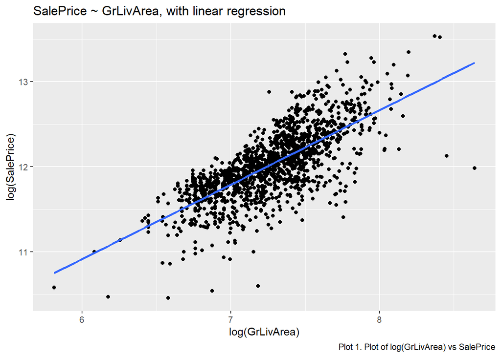

```r
ggplot(train, aes(log(GrLivArea), log(SalePrice))) +
  geom_point() +
  geom_smooth(method = "lm", se = F) +
  labs(title = "SalePrice ~ GrLivArea, with linear regression", caption="Plot 1. Plot of log(GrLivArea) vs SalePrice")
```

> 2.FullBath:

[figure not shown]

```r
ggplot(train, aes((FullBath), log(SalePrice))) +
  geom_point() +
  geom_smooth(method = "lm", se = F) +
  labs(title = "SalePrice ~ OverallQual, with linear regression",caption="Plot 2. Plot of FullBath vs log(SalePrice)")
```

> 3.GarageArea:

In the western part of the world, it is more common that people travel through their personal vehicles. The type and luxury of the vehicle directly depends on the families affordability. With the size of the vehicle, the garage size and house price also changes accordingly. The scatterplot also shows this positive correlation.

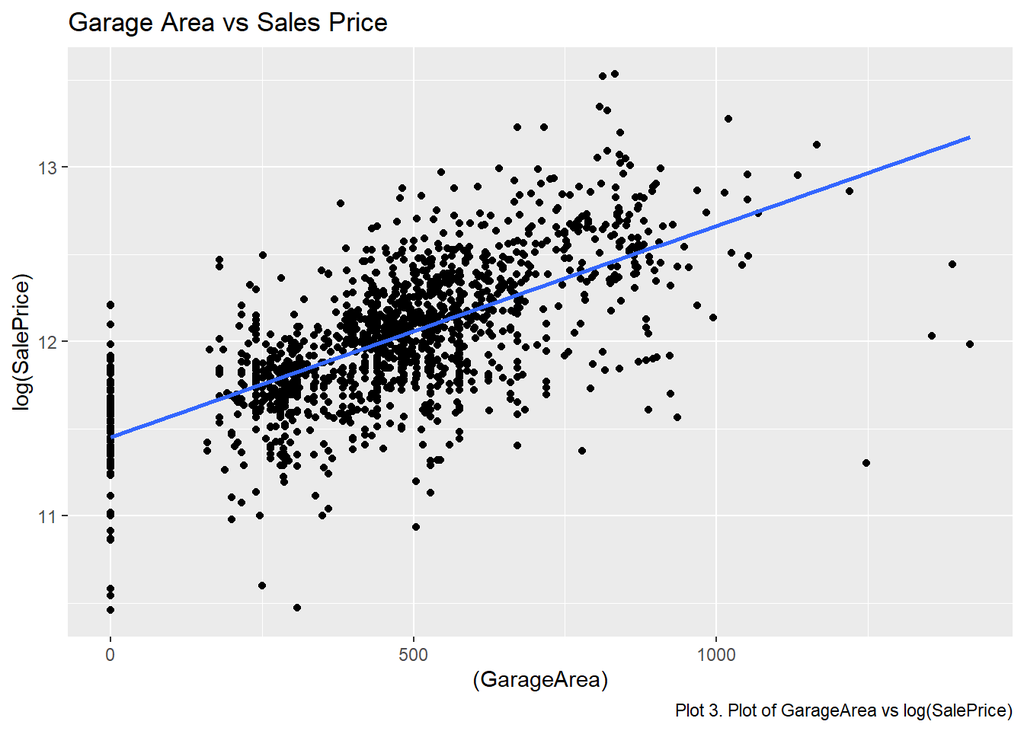

```r
train %>%
  ggplot(aes((GarageArea), log(SalePrice))) + geom_point() + geom_smooth(method = "lm", se = F) +
  labs(title="Garage Area vs Sales Price",caption="Plot 3. Plot of GarageArea vs log(SalePrice)")
```

> 4. Neighborhood:

The selling price of a house can be significantly impacted by its surrounding community. Homes in desirable neighborhoods with access to parks, restaurants, retail malls, excellent schools, low crime rates, and other amenities typically sell for more money than homes in less desirable areas.

Creating the summary table for the neighborhood using mean house price for every neighborhood.

```r
train %>%
  group_by(Neighborhood) %>%
  summarise(mean_average_sale_price = mean(SalePrice)) %>%
  arrange(desc(mean_average_sale_price)) %>%
  head(10)%>%
  gt(caption = "Table 5. Table of Neighborhood group along with their average sale price.")
```

Table 5. Table of Neighborhood group along with their average sale price.

| Neighborhood | mean_average_sale_price |
| --- | --- |
| NoRidge | 335295.3 |
| NridgHt | 316270.6 |
| StoneBr | 310499.0 |
| Timber | 242247.4 |
| Veenker | 238772.7 |
| Somerst | 225379.8 |
| ClearCr | 212565.4 |
| Crawfor | 210624.7 |
| CollgCr | 197965.8 |
| Blmngtn | 194870.9 |

The summary table shows that NoRidge has the highest house price followed by NridgHt and StoneBr.

Since, Neighborhood is a character variable, the correlation matrix cannot be used to measure the affect on Sales Price. But, we can use linear regression model to model for the Neighborhood and the target variable SalePrice.

```r
model1<- lm(SalePrice~Neighborhood,data=train)
summary(model1)
```

```
##
## Call:
## lm(formula = SalePrice ~ Neighborhood, data = train)
##
## Residuals:
##     Min      1Q  Median      3Q     Max
## -162271  -27552   -5324   19685  419705
##
## Coefficients:
##                     Estimate Std. Error t value Pr(>|t|)
## (Intercept)           194871      13097  14.879  < 2e-16 ***
## NeighborhoodBlueste   -57371      40367  -1.421 0.155463
## NeighborhoodBrDale    -90377      18809  -4.805 1.71e-06 ***
## NeighborhoodBrkSide   -70037      14893  -4.703 2.81e-06 ***
## NeighborhoodClearCr    17695      16603   1.066 0.286721
## NeighborhoodCollgCr     3095      13819   0.224 0.822820
## NeighborhoodCrawfor    15754      15123   1.042 0.297712
## NeighborhoodEdwards   -66651      14166  -4.705 2.78e-06 ***
## NeighborhoodGilbert    -2016      14437  -0.140 0.888944
## NeighborhoodIDOTRR    -94747      15822  -5.988 2.67e-09 ***
## NeighborhoodMeadowV   -96294      18522  -5.199 2.29e-07 ***
## NeighborhoodMitchel   -38601      15200  -2.540 0.011204 *
## NeighborhoodNAmes     -49024      13582  -3.609 0.000318 ***
## NeighborhoodNoRidge   140424      15577   9.015  < 2e-16 ***
## NeighborhoodNPkVill   -52176      22260  -2.344 0.019217 *
## NeighborhoodNridgHt   121400      14470   8.390  < 2e-16 ***
## NeighborhoodNWAmes     -5821      14542  -0.400 0.689011
## NeighborhoodOldTown   -66646      14047  -4.744 2.30e-06 ***
## NeighborhoodSawyer    -58078      14523  -3.999 6.69e-05 ***
## NeighborhoodSawyerW    -8315      14864  -0.559 0.575974
## NeighborhoodSomerst    30509      14333   2.129 0.033456 *
## NeighborhoodStoneBr   115628      16975   6.812 1.42e-11 ***
## NeighborhoodSWISU     -52280      16975  -3.080 0.002111 **
## NeighborhoodTimber     47377      15756   3.007 0.002686 **
## NeighborhoodVeenker    43902      20895   2.101 0.035810 *
## ---
## Signif. codes:  0 '***' 0.001 '**' 0.01 '*' 0.05 '.' 0.1 ' ' 1
##
## Residual standard error: 54000 on 1435 degrees of freedom
## Multiple R-squared:  0.5456, Adjusted R-squared:  0.538
## F-statistic: 71.78 on 24 and 1435 DF,  p-value: < 2.2e-16
```

We can see that R-squared value is 0.538 and hence Neighborhood is a good predictor for sales price. In general, costly neighborhoods have high quality houses. An interaction between Neighborhood and OverallQual shows a significant rise in R2.

```r
model1<- lm(SalePrice~Neighborhood*OverallQual,data=train)
summary(model1)
```

```
##
## Call:
## lm(formula = SalePrice ~ Neighborhood * OverallQual, data = train)
##
## Residuals:
##     Min      1Q  Median      3Q     Max
## -126003  -21524   -2287   16362  242773
##
## Coefficients: (2 not defined because of singularities)
##                                 Estimate Std. Error t value Pr(>|t|)
## (Intercept)                       -57693     178000  -0.324  0.74590
## NeighborhoodBlueste               -15967      41183  -0.388  0.69829
## NeighborhoodBrDale                265648     214573   1.238  0.21591
## NeighborhoodBrkSide                65054     179412   0.363  0.71696
## NeighborhoodClearCr               102778     183606   0.560  0.57572
## NeighborhoodCollgCr                -6367     179194  -0.036  0.97166
## NeighborhoodCrawfor               -31485     181267  -0.174  0.86213
## NeighborhoodEdwards                94115     178690   0.527  0.59849
## NeighborhoodGilbert               101744     181866   0.559  0.57595
## NeighborhoodIDOTRR                 73942     180160   0.410  0.68156
## NeighborhoodMeadowV                14961     191393   0.078  0.93770
## NeighborhoodMitchel                50829     181762   0.280  0.77979
## NeighborhoodNAmes                  53370     178823   0.298  0.76540
## NeighborhoodNoRidge              -522000     187163  -2.789  0.00536 **
## NeighborhoodNPkVill               -10772      33267  -0.324  0.74612
## NeighborhoodNridgHt              -227761     181896  -1.252  0.21072
## NeighborhoodNWAmes                108402     182477   0.594  0.55257
## NeighborhoodOldTown                40179     178698   0.225  0.82214
## NeighborhoodSawyer                150670     183371   0.822  0.41141
## NeighborhoodSawyerW               -37751     181385  -0.208  0.83516
## NeighborhoodSomerst               -29229     182152  -0.160  0.87254
## NeighborhoodStoneBr              -410700     201565  -2.038  0.04178 *
## NeighborhoodSWISU                 125244     182586   0.686  0.49286
## NeighborhoodTimber                 34948     182175   0.192  0.84790
## NeighborhoodVeenker                -1687     188665  -0.009  0.99287
## OverallQual                        35193      24768   1.421  0.15557
## NeighborhoodBlueste:OverallQual       NA         NA      NA       NA
## NeighborhoodBrDale:OverallQual    -53384      32471  -1.644  0.10039
## NeighborhoodBrkSide:OverallQual   -11939      25144  -0.475  0.63498
## NeighborhoodClearCr:OverallQual    -6772      25890  -0.262  0.79368
```

[output cut: 11 more lines]

```
## NeighborhoodNWAmes:OverallQual    -13334      25559  -0.522  0.60195
## NeighborhoodOldTown:OverallQual    -8151      24932  -0.327  0.74376
## NeighborhoodSawyer:OverallQual    -26477      26258  -1.008  0.31345
## NeighborhoodSawyerW:OverallQual     9412      25363   0.371  0.71061
## NeighborhoodSomerst:OverallQual     7371      25316   0.291  0.77098
## NeighborhoodStoneBr:OverallQual    60259      27329   2.205  0.02762 *
## NeighborhoodSWISU:OverallQual     -21399      25832  -0.828  0.40759
## NeighborhoodTimber:OverallQual      1828      25339   0.072  0.94251
## NeighborhoodVeenker:OverallQual     9127      26398   0.346  0.72959
## ---
## Signif. codes:  0 '***' 0.001 '**' 0.01 '*' 0.05 '.' 0.1 ' ' 1
##
## Residual standard error: 38930 on 1412 degrees of freedom
## Multiple R-squared:  0.7676, Adjusted R-squared:  0.7598
## F-statistic: 99.22 on 47 and 1412 DF,  p-value: < 2.2e-16
```

Below is the plot between Neighborhood along with OverallQual and Sales price.

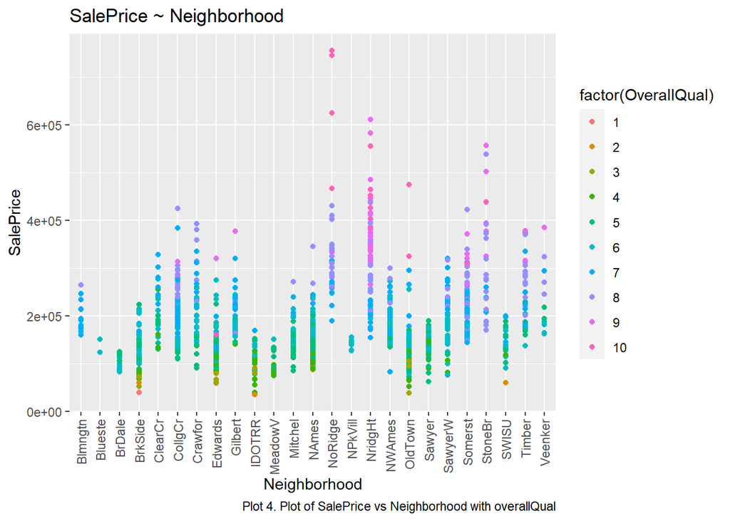

```r
ggplot(train, aes(Neighborhood, SalePrice,col=factor(OverallQual))) +
  geom_point() +
  labs(title = "SalePrice ~ Neighborhood",caption="Plot 4. Plot of SalePrice vs Neighborhood with overallQual")+
  theme(axis.text.x = element_text(angle = 90, vjust = 0.5, hjust=1))
```

The plot shows that the value of Sales price of the house changes with Neighborhood. Moreover, higher overall house quality demands high house price. Thus, the sales price depends on the interaction between Neighborhood and OverallQual.

> 5.KitchenQual:

Better the kitchen quality, higher will be the Sales price of a house. KitchenQual is a character variable and the linear model is used to verify if this predictor influences the sales price of the house.

```r
model2<- lm(SalePrice~KitchenQual,data=train)
summary(model2)
```

```
##
## Call:
## lm(formula = SalePrice ~ KitchenQual, data = train)
##
## Residuals:
##     Min      1Q  Median      3Q     Max
## -242555  -32566   -4963   25037  426445
##
## Coefficients:
##               Estimate Std. Error t value Pr(>|t|)
## (Intercept)     328555       5862   56.05   <2e-16 ***
## KitchenQualFa  -222990      11067  -20.15   <2e-16 ***
## KitchenQualGd  -116439       6343  -18.36   <2e-16 ***
## KitchenQualTA  -188592       6248  -30.18   <2e-16 ***
## ---
## Signif. codes:  0 '***' 0.001 '**' 0.01 '*' 0.05 '.' 0.1 ' ' 1
##
## Residual standard error: 58620 on 1456 degrees of freedom
## Multiple R-squared:  0.4566, Adjusted R-squared:  0.4555
## F-statistic: 407.8 on 3 and 1456 DF,  p-value: < 2.2e-16
```

R- squared value is 0.455 which shows that the KitchenQual is statistically significant and important variable for the model of sales price.

```r
train %>%
  group_by(KitchenQual) %>%
  summarise(mean_average_sale_price = mean(SalePrice)) %>%
  arrange(desc(mean_average_sale_price)) %>%
   head()%>%
  gt(caption = "Table 6. Table of KitchenQual group along with their average sale price.")
```

Table 6. Table of KitchenQual group along with their average sale price.

| KitchenQual | mean_average_sale_price |
| --- | --- |
| Ex | 328554.7 |
| Gd | 212116.0 |
| TA | 139962.5 |
| Fa | 105565.2 |

The summary table shows that Ex(Excellent) rated kitchens has the highest average house price followed by Gd (Good) and TA (Typical/Average) and Fa (Fair) type has the lowest average sale price.

> 6.`1stFlrSF * TotalBsmtSF:

Using the `1stFlrSF` predictor to model the data to the SalesPrice:

```r
model1<- lm(log(SalePrice)~`1stFlrSF`,data=train)
summary(model1)
```

```
##
## Call:
## lm(formula = log(SalePrice) ~ `1stFlrSF`, data = train)
##
## Residuals:
##      Min       1Q   Median       3Q      Max
## -2.21820 -0.18662 -0.02583  0.23510  0.90917
##
## Coefficients:
##              Estimate Std. Error t value Pr(>|t|)
## (Intercept) 1.131e+01  2.660e-02  425.10   <2e-16 ***
## `1stFlrSF`  6.168e-04  2.171e-05   28.41   <2e-16 ***
## ---
## Signif. codes:  0 '***' 0.001 '**' 0.01 '*' 0.05 '.' 0.1 ' ' 1
##
## Residual standard error: 0.3206 on 1458 degrees of freedom
## Multiple R-squared:  0.3564, Adjusted R-squared:  0.3559
## F-statistic: 807.3 on 1 and 1458 DF,  p-value: < 2.2e-16
```

R2 value of 0.3559 is obtained. Checking if `1stFlrSF` has direct relation with TotalBsmtSF by using interactions.

```r
model1<- lm(log(SalePrice)~`1stFlrSF`*TotalBsmtSF,data=train)
summary(model1)
```

```
##
## Call:
## lm(formula = log(SalePrice) ~ `1stFlrSF` * TotalBsmtSF, data = train)
##
## Residuals:
##      Min       1Q   Median       3Q      Max
## -1.27569 -0.18673 -0.03759  0.22469  0.94935
##
## Coefficients:
##                          Estimate Std. Error t value Pr(>|t|)
## (Intercept)             1.100e+01  3.881e-02  283.53   <2e-16 ***
## `1stFlrSF`              4.936e-04  3.989e-05   12.38   <2e-16 ***
## TotalBsmtSF             6.480e-04  4.292e-05   15.10   <2e-16 ***
## `1stFlrSF`:TotalBsmtSF -1.753e-07  1.690e-08  -10.38   <2e-16 ***
## ---
## Signif. codes:  0 '***' 0.001 '**' 0.01 '*' 0.05 '.' 0.1 ' ' 1
##
## Residual standard error: 0.2983 on 1456 degrees of freedom
## Multiple R-squared:  0.4435, Adjusted R-squared:  0.4424
## F-statistic: 386.8 on 3 and 1456 DF,  p-value: < 2.2e-16
```

The R2 value has increased from 0.355 to the 0.4424. So, let’s take this variables and visualize them.

[figure not shown]

```r
ggplot(train, aes(log(`1stFlrSF`), log(SalePrice),color=TotalBsmtSF)) +
  geom_point() +
  geom_smooth(method = "lm", se = F) +
  labs(title = "SalePrice ~ TotRmsAbvGrd, with linear regression",caption="Plot 5. Plot of SalePrice vs log(`1stFlrSF`) along with TotalBsmtSF")
```

> 7. BldgType

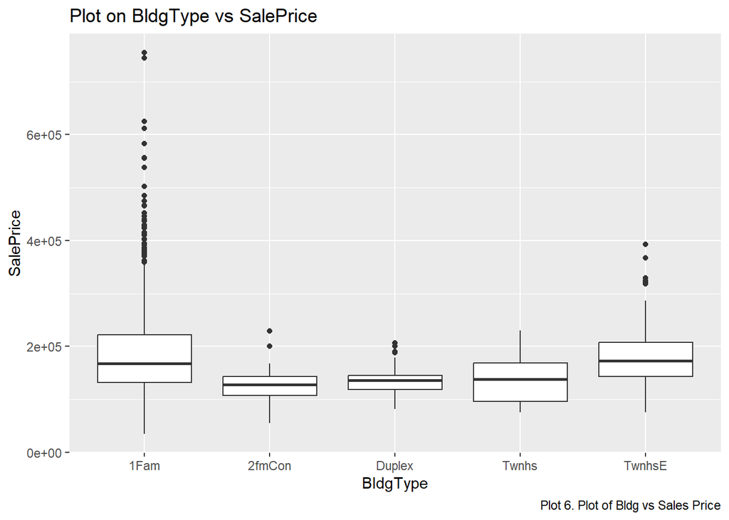

```r
ggplot(train,aes(x=BldgType,y=SalePrice)) +
  geom_boxplot()+
  labs(title="Plot on BldgType vs SalePrice", caption="Plot 6. Plot of Bldg vs Sales Price")
```

### Cross-Validation

Cross-Validation is the method to divide the train data into two folds (mostly 70-30 split). One is train_fold and the other is validation_fold. We train the model on the train_fold and validate it on the validation_fold.

```r
set.seed(124)
# Randomly sample 70% of the rows
index <- sample(x = 1:nrow(train), size = nrow(train)*.7, replace = F)
head(index) # These are row numbers
```

```
## [1] 1345  167 1002 1435  261  728
```

```r
# Subset train using the index to create train_fold
train_fold <- train[index, ]
# Subset the remaining row to create validation fold.
validation_fold <- train[-index, ]
```

> This gives a train_fold with 70% data and validation_fold with 30% data. Fitting the model with the train_fold and testing it on the validation_fold.

### Linear Regression Model

Developing the model using the variables or predictors described above.

```r
# Building the model.

model<-   lm(log(SalePrice) ~ Neighborhood * OverallQual + log(GrLivArea) + TotalBsmtSF * `1stFlrSF`+ MasVnrArea  + KitchenQual + Alley + MSZoning + Utilities + LotArea + OverallCond + BldgType+YearBuilt+FullBath+GarageArea  , data = train_fold)

summary(model) # Summary of the model.
```

```
##
## Call:
## lm(formula = log(SalePrice) ~ Neighborhood * OverallQual + log(GrLivArea) +
##     TotalBsmtSF * `1stFlrSF` + MasVnrArea + KitchenQual + Alley +
##     MSZoning + Utilities + LotArea + OverallCond + BldgType +
##     YearBuilt + FullBath + GarageArea, data = train_fold)
##
## Residuals:
##      Min       1Q   Median       3Q      Max
## -0.71709 -0.06464  0.00041  0.06782  0.42146
##
## Coefficients: (2 not defined because of singularities)
##                                   Estimate Std. Error t value Pr(>|t|)
## (Intercept)                     -1.854e-01  1.197e+00  -0.155 0.876951
## NeighborhoodBlueste              1.286e-01  1.958e-01   0.657 0.511561
## NeighborhoodBrDale               1.004e+00  1.036e+00   0.970 0.332478
## NeighborhoodBrkSide              9.427e-01  9.427e-01   1.000 0.317531
## NeighborhoodClearCr              9.794e-01  9.533e-01   1.027 0.304507
## NeighborhoodCollgCr              9.405e-01  9.409e-01   1.000 0.317757
## NeighborhoodCrawfor              7.823e-01  9.498e-01   0.824 0.410335
## NeighborhoodEdwards              1.107e+00  9.404e-01   1.178 0.239267
## NeighborhoodGilbert              1.059e+00  9.472e-01   1.118 0.263882
## NeighborhoodIDOTRR               8.283e-01  9.485e-01   0.873 0.382714
## NeighborhoodMeadowV              1.137e+00  9.751e-01   1.166 0.244088
## NeighborhoodMitchel              6.840e-01  9.533e-01   0.718 0.473237
## NeighborhoodNAmes                9.905e-01  9.410e-01   1.053 0.292764
## NeighborhoodNoRidge              3.205e-01  9.693e-01   0.331 0.741011
## NeighborhoodNPkVill              1.755e-01  1.565e-01   1.121 0.262489
## NeighborhoodNridgHt              5.440e-01  9.444e-01   0.576 0.564766
## NeighborhoodNWAmes               1.072e+00  9.538e-01   1.124 0.261440
## NeighborhoodOldTown              6.931e-01  9.404e-01   0.737 0.461316
## NeighborhoodSawyer               1.032e+00  9.534e-01   1.083 0.279247
## NeighborhoodSawyerW              7.238e-01  9.500e-01   0.762 0.446306
## NeighborhoodSomerst              8.039e-01  9.551e-01   0.842 0.400139
## NeighborhoodStoneBr             -2.855e-01  1.113e+00  -0.257 0.797588
## NeighborhoodSWISU                1.146e+00  9.494e-01   1.207 0.227646
## NeighborhoodTimber               7.216e-01  9.521e-01   0.758 0.448714
## NeighborhoodVeenker              5.021e-01  9.624e-01   0.522 0.601968
## OverallQual                      1.710e-01  1.324e-01   1.291 0.196851
## log(GrLivArea)                   4.063e-01  2.184e-02  18.605  < 2e-16 ***
```

[output cut: 38 more lines]

```
## NeighborhoodOldTown:OverallQual -8.608e-02  1.328e-01  -0.648 0.516902
## NeighborhoodSawyer:OverallQual  -1.513e-01  1.365e-01  -1.109 0.267777
## NeighborhoodSawyerW:OverallQual -9.147e-02  1.344e-01  -0.681 0.496259
## NeighborhoodSomerst:OverallQual -1.080e-01  1.341e-01  -0.805 0.420792
## NeighborhoodStoneBr:OverallQual  4.578e-02  1.517e-01   0.302 0.762797
## NeighborhoodSWISU:OverallQual   -1.632e-01  1.349e-01  -1.210 0.226602
## NeighborhoodTimber:OverallQual  -9.047e-02  1.341e-01  -0.675 0.499915
## NeighborhoodVeenker:OverallQual -4.373e-02  1.357e-01  -0.322 0.747362
## TotalBsmtSF:`1stFlrSF`          -1.046e-07  1.848e-08  -5.660 2.01e-08 ***
## ---
## Signif. codes:  0 '***' 0.001 '**' 0.01 '*' 0.05 '.' 0.1 ' ' 1
##
## Residual standard error: 0.1252 on 949 degrees of freedom
## Multiple R-squared:  0.909,  Adjusted R-squared:  0.9022
## F-statistic: 133.6 on 71 and 949 DF,  p-value: < 2.2e-16
```

> R-squared value obtained is 0.902.

Validating the model and calculating the RMSE and R2 for the validation fold using the developed model.

```r
predictions <- predict(model, newdata = validation_fold) # Predicting the model with new data.
# Calculating the rmse.
rmse <- function(observed, predicted) sqrt(mean((observed - predicted)^2))

#Calculating the R2.
R2 <- function(observed, predicted){
  TSS <- sum((observed - mean(observed))^2)
  RSS <- sum((observed - predicted)^2)
  1- RSS/TSS
}

rmse(validation_fold$SalePrice, exp(predictions))
```

```
## [1] 26839.81
```

```r
R2(validation_fold$SalePrice, exp(predictions))
```

```
## [1] 0.8952163
```

> The model has r-squared of 0.895 with RMSE value of 26839.81 for the validation fold, which is more than the 0.85 benchmark value.

### Submission Model to the Kaggle

```r
submission_model <-  lm(log(SalePrice) ~ Neighborhood * OverallQual + log(GrLivArea) + TotalBsmtSF * `1stFlrSF` + MasVnrArea  + KitchenQual + Alley + MSZoning + Utilities + LotArea + TotRmsAbvGrd+YearRemodAdd + BldgType+YearBuilt+GarageArea,data=train)
summary(submission_model)
```

```
##
## Call:
## lm(formula = log(SalePrice) ~ Neighborhood * OverallQual + log(GrLivArea) +
##     TotalBsmtSF * `1stFlrSF` + MasVnrArea + KitchenQual + Alley +
##     MSZoning + Utilities + LotArea + TotRmsAbvGrd + YearRemodAdd +
##     BldgType + YearBuilt + GarageArea, data = train)
##
## Residuals:
##      Min       1Q   Median       3Q      Max
## -0.79778 -0.06405  0.00744  0.07409  0.47478
##
## Coefficients: (2 not defined because of singularities)
##                                   Estimate Std. Error t value Pr(>|t|)
## (Intercept)                     -9.592e-01  9.499e-01  -1.010  0.31277
## NeighborhoodBlueste              1.941e-01  1.413e-01   1.373  0.16988
## NeighborhoodBrDale               1.021e+00  7.265e-01   1.406  0.16009
## NeighborhoodBrkSide              4.955e-01  6.059e-01   0.818  0.41364
## NeighborhoodClearCr              5.311e-01  6.200e-01   0.857  0.39181
## NeighborhoodCollgCr              8.021e-01  6.049e-01   1.326  0.18506
## NeighborhoodCrawfor              5.356e-01  6.128e-01   0.874  0.38230
## NeighborhoodEdwards              8.032e-01  6.039e-01   1.330  0.18372
## NeighborhoodGilbert              8.393e-01  6.137e-01   1.368  0.17165
## NeighborhoodIDOTRR               4.534e-01  6.122e-01   0.741  0.45901
## NeighborhoodMeadowV              7.059e-01  6.486e-01   1.088  0.27668
## NeighborhoodMitchel              5.666e-01  6.139e-01   0.923  0.35625
## NeighborhoodNAmes                7.338e-01  6.038e-01   1.215  0.22446
## NeighborhoodNoRidge              3.606e-02  6.310e-01   0.057  0.95443
## NeighborhoodNPkVill              1.614e-01  1.132e-01   1.425  0.15444
## NeighborhoodNridgHt              3.873e-01  6.134e-01   0.631  0.52783
## NeighborhoodNWAmes               7.562e-01  6.159e-01   1.228  0.21975
## NeighborhoodOldTown              4.143e-01  6.031e-01   0.687  0.49224
## NeighborhoodSawyer               6.892e-01  6.190e-01   1.113  0.26577
## NeighborhoodSawyerW              4.657e-01  6.141e-01   0.758  0.44842
## NeighborhoodSomerst              6.200e-01  6.177e-01   1.004  0.31572
## NeighborhoodStoneBr              4.446e-01  6.837e-01   0.650  0.51559
## NeighborhoodSWISU                7.751e-01  6.165e-01   1.257  0.20892
## NeighborhoodTimber               5.865e-01  6.159e-01   0.952  0.34109
## NeighborhoodVeenker              4.836e-01  6.362e-01   0.760  0.44737
## OverallQual                      1.423e-01  8.355e-02   1.703  0.08880 .
## log(GrLivArea)                   3.711e-01  2.540e-02  14.611  < 2e-16 ***
```

[output cut: 38 more lines]

```
## NeighborhoodOldTown:OverallQual -4.418e-02  8.415e-02  -0.525  0.59969
## NeighborhoodSawyer:OverallQual  -9.380e-02  8.867e-02  -1.058  0.29030
## NeighborhoodSawyerW:OverallQual -5.860e-02  8.594e-02  -0.682  0.49548
## NeighborhoodSomerst:OverallQual -8.517e-02  8.557e-02  -0.995  0.31972
## NeighborhoodStoneBr:OverallQual -4.259e-02  9.267e-02  -0.460  0.64586
## NeighborhoodSWISU:OverallQual   -1.036e-01  8.716e-02  -1.189  0.23469
## NeighborhoodTimber:OverallQual  -7.401e-02  8.559e-02  -0.865  0.38732
## NeighborhoodVeenker:OverallQual -3.828e-02  8.896e-02  -0.430  0.66704
## TotalBsmtSF:`1stFlrSF`          -1.032e-07  8.564e-09 -12.053  < 2e-16 ***
## ---
## Signif. codes:  0 '***' 0.001 '**' 0.01 '*' 0.05 '.' 0.1 ' ' 1
##
## Residual standard error: 0.1309 on 1388 degrees of freedom
## Multiple R-squared:  0.8978, Adjusted R-squared:  0.8926
## F-statistic: 171.8 on 71 and 1388 DF,  p-value: < 2.2e-16
```

Predicting the SalePrice value for the test data using the submission model.

```r
submission_predictions <- predict(submission_model, newdata = test)
```

Creating a new dataframe in the required format for Kaggle to store the predicted values.

```r
submission <- test %>%
  select(Id) %>%
  mutate(SalePrice = exp(submission_predictions))
```

```r
submission%>%
  head(6)%>%
  gt(caption = "Table 6. Table of submission model along with the fitted values on the test data .")
```

Table 6. Table of submission model along with the fitted values on the test data .

| Id | SalePrice |
| --- | --- |
| 1461 | 124025.1 |
| 1462 | 155457.6 |
| 1463 | 183412.0 |
| 1464 | 191131.0 |
| 1465 | 216779.1 |
| 1466 | 176749.0 |

Generating the submission file.

```r
write.csv(submission,"submission.csv")
```

### Residual Plot

Plotting the residual values from the submission model by taking the log of the SalePrice as the fitted values of SalePrice in the model are on log scale.

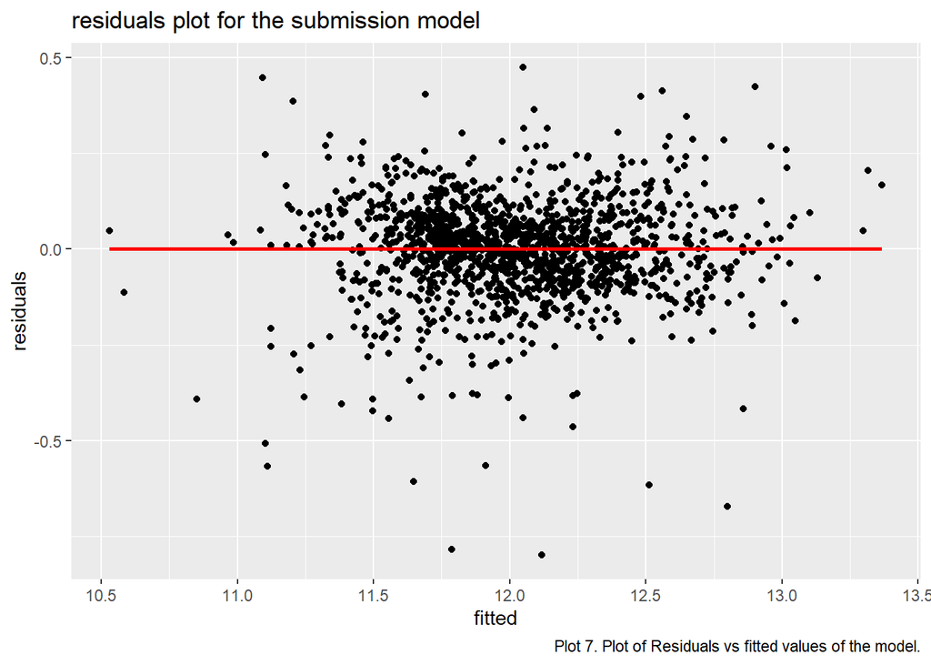

```r
train %>%
  mutate(fitted = fitted(submission_model),
         residuals = log(SalePrice) - (fitted)) %>%
   ggplot(aes(fitted, residuals)) +
  geom_point() +
  geom_smooth(method = "lm", se = F, col = "red") +
  labs(title = "residuals plot for the submission model",caption="Plot 7. Plot of Residuals vs fitted values of the model.")
```

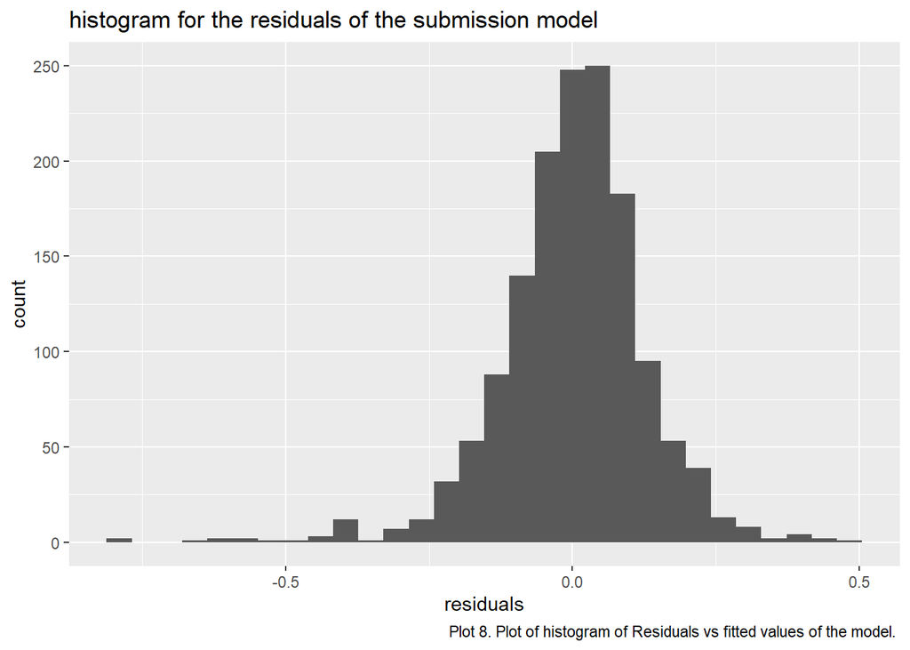

```r
train %>%
  mutate(fitted = fitted(submission_model),
         residuals = log(SalePrice) - (fitted)) %>%
  ggplot(aes(x=residuals))+
  geom_histogram() +
  labs(title = "histogram for the residuals of the submission model",caption="Plot 8. Plot of histogram of Residuals vs fitted values of the model. ")
```

> The plot between the fitted values of the Sale price and residual values shows no identifiable pattern and the residual histogram is also nearly normal. This assures that the model is a good fit to the data.

### Team Members and their contribution

> Team Members - Abhiram Mannam, Abinav Yadamani, Gnana Chaithanya Rawali Male, Neil Samuel Sadanand Pulukuri.

> Contribution: All the members have spent significant amount of the time on the project. Below listed are the individual contribution details.

> Abhiram Mannam: Developing Linear Regression model and residual plots for the model.

> Abinav Yadamani: Prepared the project notebook and assisted in developing the models along with the analysis of interacting variables in the model.

> Gnana Chaithanya Rawali Male: Selecting the variables for the model and plotted graphs to support why the selected predictor variables have been chosen for developing the model.

> Neil Samuel Pulukuri: Cleaned the Train and Test datasets and created summary tables and assisted in reviewing the documentation.

### Conclusion

> In conclusion, we have taken the predictors and their interactions to predict the target variable SalePrice. We cleaned the train and test data and divided into train_fold and validation_fold with 70-30 split. We get R2 value of around 0.90 for train_fold and R2 value of .89 with rmse of 26839.81 on the validation set. This shows that the model passes the threshold R2 of.85.

> Uploading the generated submission file to Kaggle will get the log RMSE score of 0.13776.